## Bananas

I find it challenging to get a clear understanding of each year from this graph.

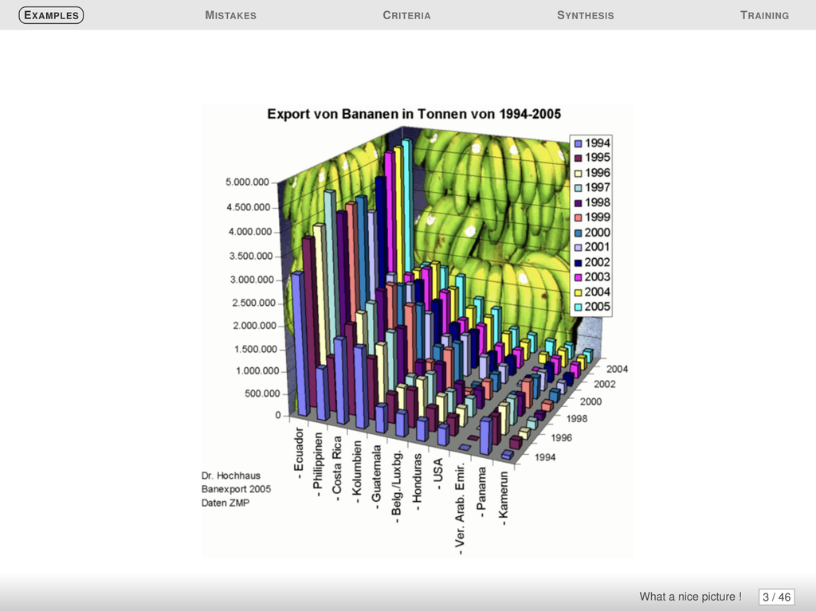

Bananas

#### Data

- Type of graphic adapted
- Interpolation make sense
- Sufficient number of points
- Building method clear
- Confidence intervals visualized
- Appropriate steps for histograms
- Histograms visualize probabilities

#### Graphical objects

- Graphical objects are readable on any support
- Standard color range
- Axis identified and labelled
- Scales units are explicit
- No ambiguity when curves cross
- Grid helps reading

#### Annotation

- Axis are labelled by quantities
- Labels of the axis are clear, and self contained
- Units are indicated on the axis
- Axes are oriented from bottom-left to top-right
- Origin should be (0,0), if not it should be clearly justified
- No Hole on the axes
- the order’s of graph/histogram bar is based on classical ordering
- Curves and Bar has legend

#### Information

- Curves on the same scale
- Less than 6 curves
- Compare curves on same graphics
- A curve cannot be removed without reducing infos
- The graphic gives relevant infos
- If showing average, don’t forget the error bars
- It is not possible to remove object without altering readability

#### Context

- All symbols used are defined and references
- The graphics is the most appropriate representation for the data
- The graphic has a title
- The title is meaningful and self contained
- The graphic is referenced in text
- The text comment the figure